# Happiness Around The World

The pursuit of happiness is a fundamental human endeavor. Using a report on world happiness, we can delve into some factors that may contribute to happiness or lack thereof. It is important to understand how different factors contribute to happiness as we can use this information to help build a happier world.

We will import Numpy, Pandas, and Matplotlib in order to process and visualize all of the data.

```python
import numpy as np
import pandas as pd
import matplotlib.pyplot as plt
```

Using Pandas, we will read the csv file then create a data frame using that information.

```python
data = pd.read_csv('happiness.csv',sep=',')
df = pd.DataFrame(data)
```

# Which Region is Happiest Overall?

Now we are going to create a plot that will assess the Happiness Score of each country and group it by region. The Happiness Score in this dataset represents peoples' answer when asked the question: "How would you rate your happiness on a scale of 1 to 10. We will use .groupby() to group the scores by region. Then we will use .plot() to make a line graph to visualize the data.

```
Region
Australia and New Zealand          7.323500
Central and Eastern Europe         5.370690
Eastern Asia                       5.624167
Latin America and Caribbean        6.101750
Middle East and Northern Africa    5.386053
North America                      7.254000
Southeastern Asia                  5.338889
Southern Asia                      4.563286
Sub-Saharan Africa                 4.136421
Western Europe                     6.685667
Name: Happiness Score, dtype: float64
```

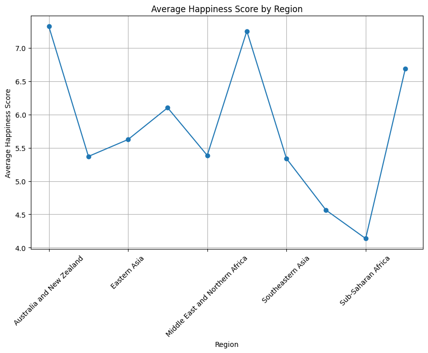

```python
# Group by region and calculate average happiness score
average_happiness_by_region = df.groupby('Region')['Happiness Score'].mean()
print(average_happiness_by_region)
# Plot average happiness score for each region over time
average_happiness_by_region.plot(kind='line', marker='o', figsize=(10, 6))
plt.title('Average Happiness Score by Region')
plt.xlabel('Region')
plt.ylabel('Average Happiness Score')
plt.xticks(rotation=45)
plt.grid(True)
plt.show()
```

We can see from looking at this graph that Australia and New Zealand have the highest average happiness score by region with a score of 7.32, whereas Sub-Saharan Africa has the lowest with a score of 4.13. Now we have to determine what are some conclusions that we can draw from this information? We also need to ask if this information is truly representative of the average happiness. We need to take into consideration how many countries are in each region.

# Which Regions Have Above Average Happiness?

To do this, we will sort the number of countries in the top 50% of the data by region. This will give us another perspective on happiness by region as we will be able to see the general happiness trend by region. We will then plot the information in a bar graph for a visual representation. We must first sort all of the scores in descending order, then we can use .head() to get the values in the top 50%. We can then use Matplotlib to make a bar graph.

```
                            Region  Country  Rank
3      Latin America and Caribbean       21     1
8                   Western Europe       19     2
1       Central and Eastern Europe       16     3
4  Middle East and Northern Africa        9     4
2                     Eastern Asia        4     5
6                Southeastern Asia        3     6
0        Australia and New Zealand        2     8
5                    North America        2     8
7               Sub-Saharan Africa        2     8
```

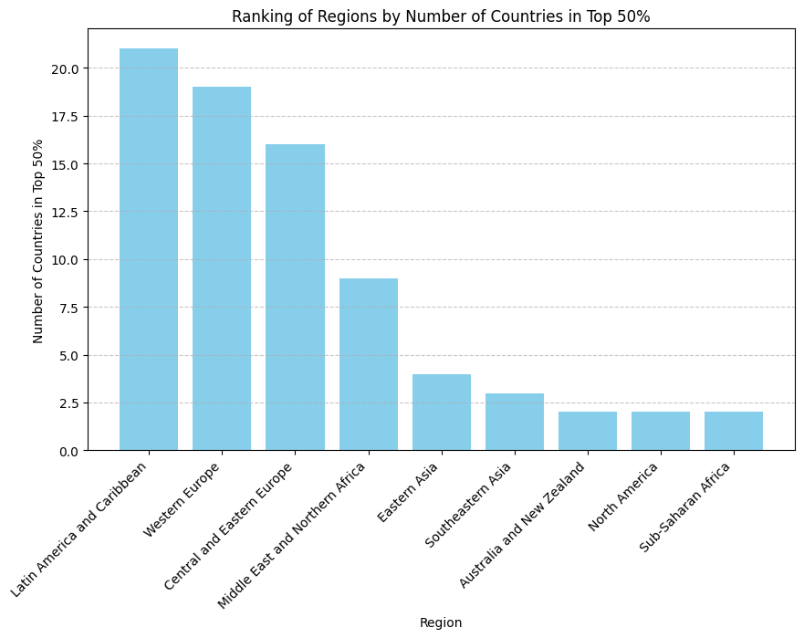

```python
top_countries = df.sort_values(by='Happiness Score', ascending=False).head(78)
region_counts = top_countries.groupby('Region')['Country'].nunique().reset_index()
region_counts['Rank'] = region_counts['Country'].rank(ascending=False).astype(int)
region_counts_sorted = region_counts.sort_values(by='Rank')
print(region_counts_sorted)

plt.figure(figsize=(10, 6))
plt.bar(region_counts_sorted['Region'], region_counts_sorted['Country'], color='skyblue')
plt.xlabel('Region')
plt.ylabel('Number of Countries in Top 50%')
plt.title('Ranking of Regions by Number of Countries in Top 50%')
plt.xticks(rotation=45, ha='right')
plt.grid(axis='y', linestyle='--', alpha=0.7)
plt.show()
```

# Which Regions Are The Happpiest?

We can narrow this down even further by looking at the countries in the top 20% grouped by region. We can use a similar method to the previous graph but adjust .head() to get the proper amount of values.

```
                            Region  Country  Rank
6                   Western Europe       14     1
2      Latin America and Caribbean        9     2
0        Australia and New Zealand        2     4
3  Middle East and Northern Africa        2     4
4                    North America        2     4
1       Central and Eastern Europe        1     6
5                Southeastern Asia        1     6
```

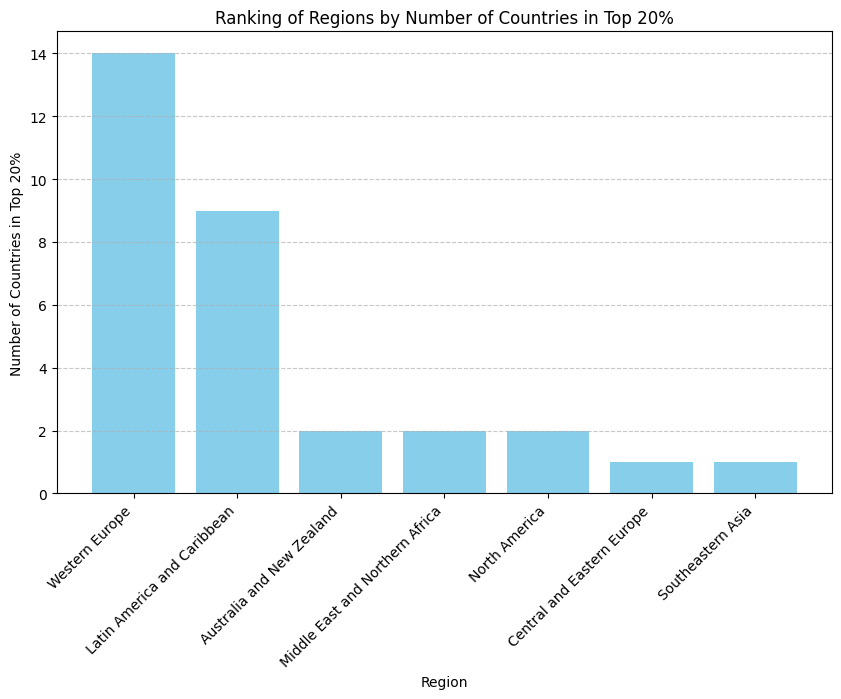

```python
top_countries= df.sort_values(by='Happiness Score', ascending=False).head(31)
region_counts = top_countries.groupby('Region')['Country'].nunique().reset_index()
region_counts['Rank'] = region_counts['Country'].rank(ascending=False).astype(int)
region_counts_sorted = region_counts.sort_values(by='Rank')
print(region_counts_sorted)

plt.figure(figsize=(10, 6))
plt.bar(region_counts_sorted['Region'], region_counts_sorted['Country'], color='skyblue')
plt.xlabel('Region')
plt.ylabel('Number of Countries in Top 20%')
plt.title('Ranking of Regions by Number of Countries in Top 20%')
plt.xticks(rotation=45, ha='right')
plt.grid(axis='y', linestyle='--', alpha=0.7)
plt.show()
```

This graph gives us a closer look at the situation and can lead us to draw some more conclusions about the happiness by region. From the previous graph we can see that Western Europe has 19 countries in the top 50%, but they also have 14 countries in the top 20%. This can help us conclude that Western Europe has well above average mean happiness scores. I think we can conclude Western Europe is the happiest region.

# Which Regions Are The Saddest?

Now that we have addressed which regions are the happiest, let's delve into which regions are the least happy based on their average happiness score. We will do this by sorting the values in ascending order then use .head() to get the values in the first 50% of the data. Because the values are in ascended order, this will give us the bottom 50%. We will then congregate this data in the form of a pie chart.

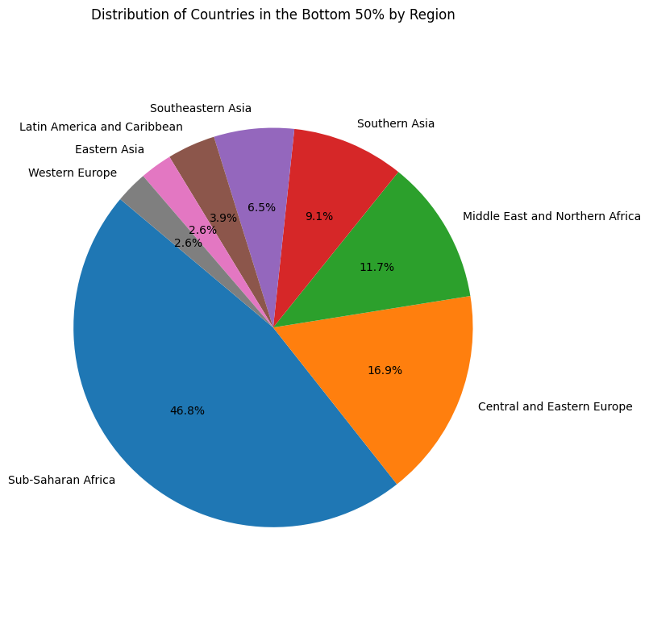

```python
#Sort the DataFrame by happiness score in ascending order
df_sorted = df.sort_values(by='Happiness Score')

#Select the bottom countries based on happiness score
bottom = df_sorted.head(77)

#Group the selected countries by region and count the number of countries in each region
bottom_counts = bottom['Region'].value_counts()

#Plot a pie chart to visualize the distribution of these countries across regions
plt.figure(figsize=(8, 8))
plt.pie(bottom_counts, labels=bottom_counts.index, autopct='%1.1f%%', startangle=140)
plt.title('Distribution of Countries in the Bottom 50% by Region')
plt.axis('equal')
plt.tight_layout()
plt.show()
```

The distribution of countries from Sub-Saharan Africa among the bottom 50% in terms of happiness score, as indicated by the pie chart, can lead to several conclusions and insights:

Regional Disparities: The high percentage of Sub-Saharan African countries among the bottom 50% suggests significant regional disparities in happiness levels compared to other regions. This highlights potential challenges and disparities in well-being within the region.

Socioeconomic Factors: Sub-Saharan Africa is characterized by various socioeconomic challenges such as poverty, inequality, political instability, and limited access to healthcare and education. These factors can contribute to lower levels of happiness and well-being among its population.

Overall, the high representation of Sub-Saharan African countries among the bottom 50% in terms of happiness score underscores the importance of addressing regional disparities and implementing solutions to enhance well-being and quality of life in the region. It serves as a call to action for policymakers, researchers, and stakeholders to work together to address the root causes of unhappiness and promote inclusive and sustainable development.

# What Is The Happiness Inequality By Region?

The standard deviation provides insight into how much individual happiness scores within each region deviate from the mean happiness score. A higher standard deviation indicates greater variability in happiness scores, suggesting that individuals within the region experience a wider range of happiness levels. We will implement this by grouping the countries by region then using .std() to calculate the standard deviation of each region. Then we will use .plot() to create a bar graph.

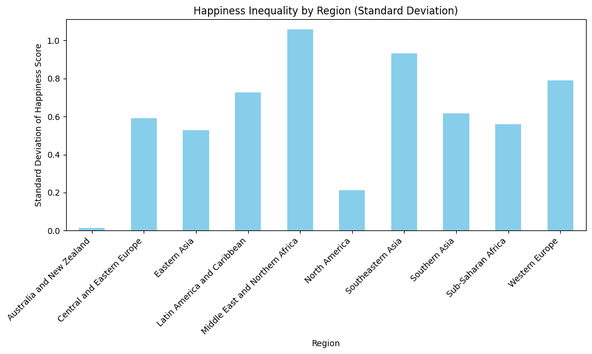

```python
#Group the data by region
grouped_by_region = df.groupby('Region')

#Calculate the standard deviation of happiness scores within each region
happiness_std_by_region = grouped_by_region['Happiness Score'].std()

#Visualize the results
plt.figure(figsize=(10, 6))
happiness_std_by_region.plot(kind='bar', color='skyblue')
plt.title('Happiness Inequality by Region (Standard Deviation)')
plt.xlabel('Region')
plt.ylabel('Standard Deviation of Happiness Score')
plt.xticks(rotation=45, ha='right')
plt.tight_layout()
plt.show()
```

Judging from this graph we can see that Australia and New Zealand have a standard deviation of almost zero. This means that the two countries have almost identical happiness scores. Middle East and Norther Africa has the highes standard deviation, meaning there is much more variation of happiness scores among the countries in the region.

# What Factors Make A Region Happy?

Now that we have established which countries and regions are the happiest and saddest, let's try to figure out some of the factors that might be affecting this. Since we established earlier that Western Europe was the happiest region we will make a range of scatter plots comparing the factors listed in the dataset to the happiness scores of Western Europe.

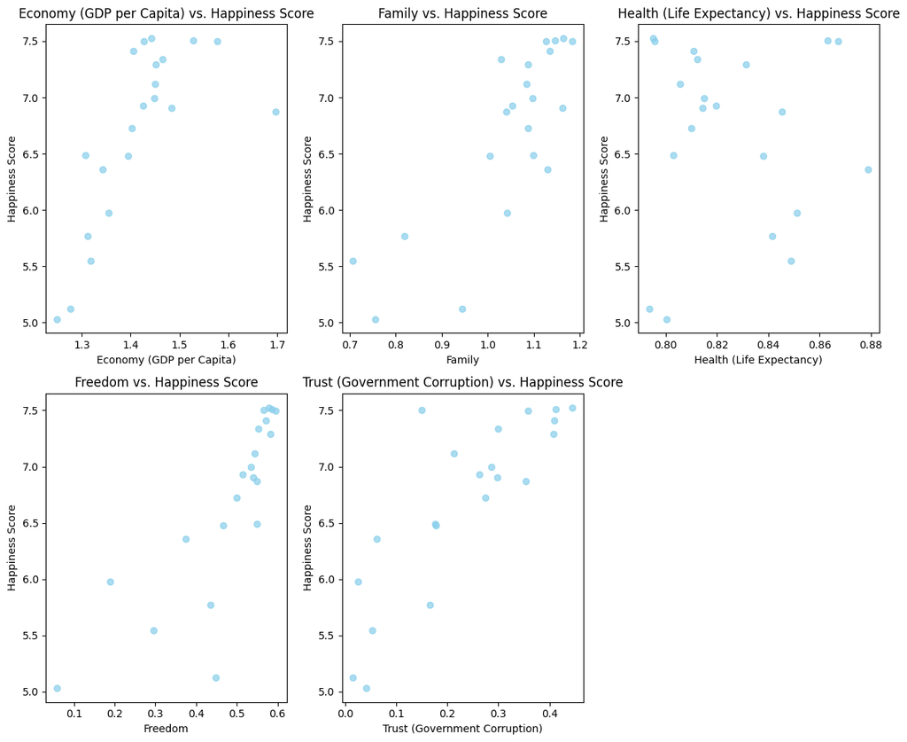

```python
#Filter the DataFrame for countries in Western Europe
western_europe_df = df[df['Region'] == 'Western Europe']

#Select relevant columns for analysis
columns_of_interest = ['Economy (GDP per Capita)', 'Family', 'Health (Life Expectancy)', 'Freedom', 'Trust (Government Corruption)', 'Happiness Score']
data_for_analysis = western_europe_df[columns_of_interest]

plt.figure(figsize=(12, 10))

for i, column in enumerate(columns_of_interest[:-1]):
    plt.subplot(2, 3, i+1)
    plt.scatter(data_for_analysis[column], data_for_analysis['Happiness Score'], color='skyblue', alpha=0.7)
    plt.title(f'{column} vs. Happiness Score')
    plt.xlabel(column)
    plt.ylabel('Happiness Score')

plt.tight_layout()
plt.show()
```

When examining the scatter plots and observing positive correlations between factors such as GDP, family, freedom, trust in government, and happiness score in Western European countries, several conclusions can be drawn:

Economic Prosperity and Well-Being: The positive correlation between GDP and happiness score suggests that higher levels of economic prosperity are associated with greater levels of happiness. This aligns with the notion that economic wealth provides individuals with resources and opportunities to fulfill their basic needs and pursue higher levels of satisfaction and well-being.

Social Support and Happiness: The positive correlation between family and happiness score indicates that strong social support networks, characterized by close familial relationships, contribute to greater happiness. This underscores the importance of social connections and interpersonal relationships in fostering well-being and emotional fulfillment.

Individual Freedom and Happiness: The positive correlation between freedom and happiness score suggests that societies that value individual freedoms and autonomy tend to have higher levels of happiness among their citizens. This may reflect the satisfaction derived from personal agency, self-determination, and the ability to pursue one's interests and goals without undue constraints.

Trust in Government and Happiness: The positive correlation between trust in government and happiness score implies that citizens' trust in their government institutions positively influences overall happiness levels. This trust may be rooted in perceptions of governmental transparency, accountability, fairness, and effectiveness in addressing societal needs and concerns.

# What Factors Make A Region Sad?

We will do the same comparison as the previous part, but this time we will examine Sub-Saharan Africa as it appears to be the saddest region.

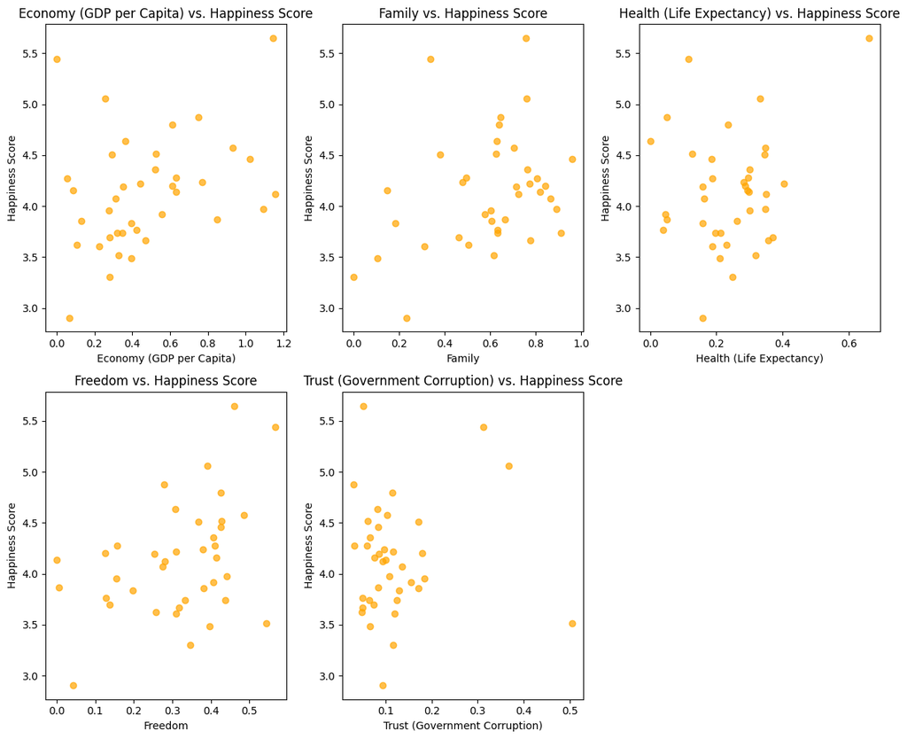

```python
# Filter the DataFrame for countries in Sub-Saharan Africa
sub_saharan_africa_df = df[df['Region'] == 'Sub-Saharan Africa']

# Select relevant columns for analysis
data_for_analysis_sub_saharan = sub_saharan_africa_df[columns_of_interest]

# Create scatter plots for each factor vs. happiness score
plt.figure(figsize=(12, 10))

for i, column in enumerate(columns_of_interest[:-1]):
    plt.subplot(2, 3, i+1)
    plt.scatter(data_for_analysis_sub_saharan[column], data_for_analysis_sub_saharan['Happiness Score'], color='orange', alpha=0.7)
    plt.title(f'{column} vs. Happiness Score')
    plt.xlabel(column)
    plt.ylabel('Happiness Score')
plt.tight_layout()
plt.show()
```

When observing that the scatter plots for factors such as GDP, family, life expectancy, freedom, and trust in government against happiness score in Sub-Saharan African countries show no significant correlation, several conclusions and insights can be drawn:

Complexity of Happiness Determinants: Unlike the positive correlations observed in Western European countries, the lack of correlation in Sub-Saharan Africa suggests that the relationship between socio-economic factors and happiness may be more nuanced and multifaceted in this region. Happiness in Sub-Saharan Africa may be influenced by a wide range of contextual, cultural, and historical factors beyond those examined in this analysis.

Socio-Economic Disparities: Sub-Saharan Africa is characterized by significant socio-economic disparities, including widespread poverty, inequality, political instability, and limited access to basic services such as healthcare and education. These disparities may contribute to the lack of clear relationships between traditional indicators of well-being and happiness score.

Cultural and Social Factors: Cultural values, social norms, community cohesion, and resilience may play a more significant role in shaping happiness levels in Sub-Saharan African countries than purely economic or governance-related factors. Cultural diversity and societal dynamics within the region may influence individuals' perceptions of happiness and well-being in ways that are not captured by conventional indicators.

With the scatterplots have a relationship of no correlation, there must be other outside factors that are contributing to Sub-Saharan Africa's low happiness score.

```python
!pip install nbconvert
```

```python
!jupyter nbconvert --to html /content/project2.ipynb
```

[output not shown]

[output cut: 133 more lines]

[output not shown]